# Binary Logistic Regression: Model Specification, Comparison, and Interpretation

Predicting survival on the Titanic

Author

Jheanelle Walters

Published

November 13, 2026

# 1. Data and exploration

This analysis uses the `titanic_train` data from the `titanic` package. After keeping passengers with complete data on survival, sex, age, and ticket class, the sample contains 714 passengers. The outcome is whether a passenger survived the sinking, and the predictors are sex, ticket class (a proxy for socioeconomic status), and age.

## Descriptive statistics

Table 1: Descriptive statistics for age

| Variable | Mean | SD | Min | Max |
| --- | --- | --- | --- | --- |
| Age (years) | 29.70 | 14.53 | 0.42 | 80.00 |

Table 2: Cell counts for the categorical variables

| Category | n | Percent (%) |
| --- | --- | --- |
| Survival |  |  |
| Died | 424 | 59.4 |
| Survived | 290 | 40.6 |
| Sex |  |  |
| Female | 261 | 36.6 |
| Male | 453 | 63.4 |
| Ticket class |  |  |
| First Class | 186 | 26.1 |
| Second Class | 173 | 24.2 |
| Third Class | 355 | 49.7 |

## Exploratory patterns

Of the 714 passengers, 290 (40.6%) survived. The sample was not evenly split across the categorical variables. About 36.6% of passengers were female, and 49.7% held third-class tickets compared with 26.1% in first class, so the cell counts are uneven, though every cell is large enough to estimate. Ages averaged 29.7 years (SD = 14.5), ranging from 0.42 to 80. The clearest pattern is that survival differed sharply by group: 75.5% of women survived compared with 20.5% of men, and 65.6% of first-class passengers survived compared with 23.9% in third class. These patterns are consistent with my expectations, which are described below.

# 2. Specify competing models

## Predictions

I expected all three predictors to be associated with survival. Given the “women and children first” practice during emergencies at the time of the Titanic sinking, I anticipated that women would have higher odds of survival than men. I also expected ticket class, which I used as an indicator of socioeconomic status, to influence survival. First-class passengers may have had easier access to lifeboats, crew members, and important information, which could have increased their chances of survival compared with third-class passengers. Similarly, I expected younger passengers to have higher odds of survival because children were often prioritized during evacuation. Overall, I anticipated that sex and ticket class would have the strongest associations with survival, while age would make a smaller additional contribution after accounting for the other two predictors.

We will estimate four nested models:

| Model | Predictors | Purpose |
| --- | --- | --- |
| mod0: Null | Intercept only | Baseline model |
| mod1: Sex | Sex | Evaluate sex |
| mod2: Sex + Pclass | Sex, Pclass | Additional contribution of ticket class |
| mod3: Sex + Pclass + Age | Sex, Pclass, Age | Additional contribution of age |

## How the intercept changes

The meaning of the intercept changes with each model because it always describes the log-odds of survival when every predictor is at its reference value. In mod1, the intercept (1.12) is the log-odds of survival for a female passenger, since female is the reference level of sex. In mod2, the intercept (2.33) is the log-odds of survival for a female passenger in first class. In mod3, the intercept (3.78) is the log-odds of survival for a female first-class passenger aged 0. Age 0 is just below the youngest passenger in the data (0.42 years), so this intercept is a baseline for the model and not a typical passenger.

# 3. Compare model performance

Table 3: Model comparison and nested likelihood-ratio tests

| Model | AIC | BIC | logLik | deviance | Residual df | Nested df | Nested χ² | Nested p |
| --- | --- | --- | --- | --- | --- | --- | --- | --- |
| mod0: Null | 966.52 | 971.09 | −482.26 | 964.52 | 713 | — | — | — |
| mod1: Sex | 754.70 | 763.84 | −375.35 | 750.70 | 712 | 1 | 213.82 | < .001 |
| mod2: + Pclass | 680.43 | 698.71 | −336.22 | 672.43 | 710 | 2 | 78.27 | < .001 |
| mod3: + Age | 657.28 | 680.14 | −323.64 | 647.28 | 709 | 1 | 25.15 | < .001 |

## Interpreting the comparisons

The best-fitting model was mod3 (sex, ticket class, and age), which had the lowest AIC (657.3) and the lowest BIC (680.1) of the four models. AIC and BIC both fell with every predictor added. AIC dropped from 966.5 in the null model to 754.7 with sex, 680.4 with ticket class, and 657.3 with age. BIC followed the same pattern, falling from 971.1 to 763.8, 698.7, and 680.1. The likelihood-ratio tests showed that each addition significantly improved fit: sex improved on the intercept-only model (χ²(1) = 213.82, p < .001), ticket class improved on sex alone (χ²(2) = 78.27, p < .001), and age improved on sex and ticket class (χ²(1) = 25.15, p < .001). AIC, BIC, and the likelihood-ratio tests therefore support the same conclusion. This agreement is expected here, because even the smallest improvement (age) is much larger than the extra penalty that BIC places on one additional parameter, which is the stricter of the two criteria with 714 passengers. The size of the improvements also shows that the predictors contributed unequally. Sex produced by far the largest gain, ticket class added a substantial improvement beyond sex, and age added the smallest but still clearly significant improvement.

# 4. Evaluate binary logistic regression diagnostics

I examined mod3, the model with the best AIC and BIC and with every likelihood-ratio test significant, as the most promising model.

## Residual diagnostics

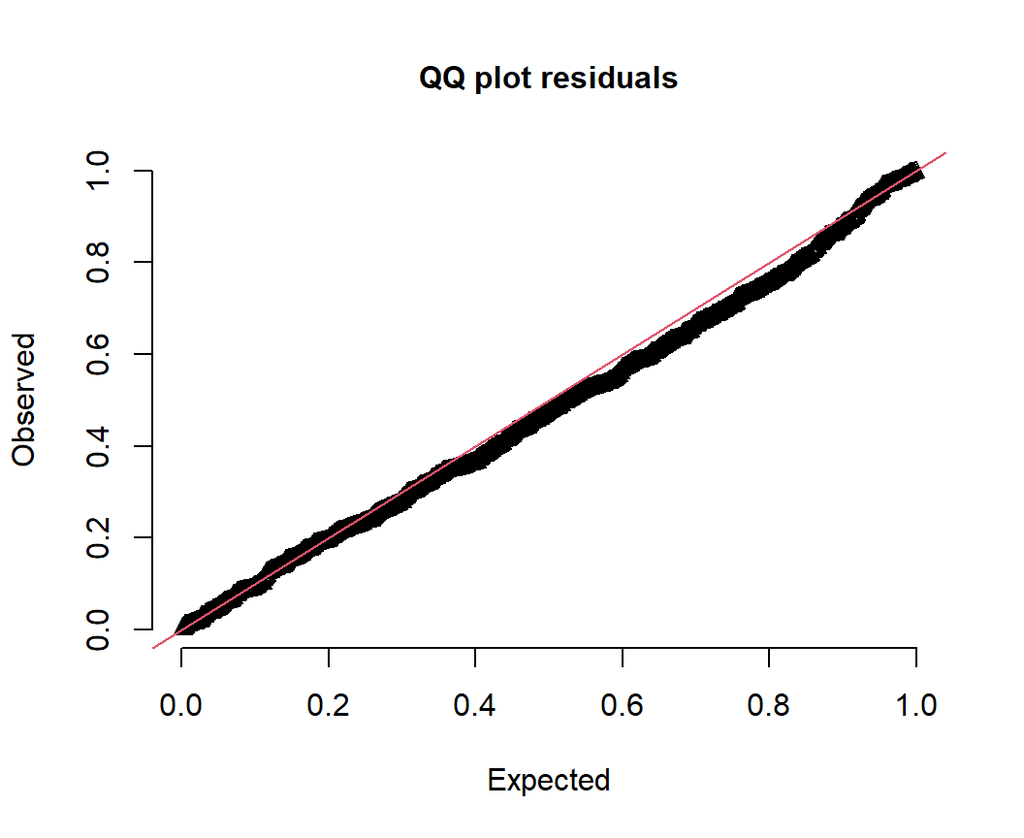

Figure 1: DHARMa QQ plot of simulated residuals for mod3

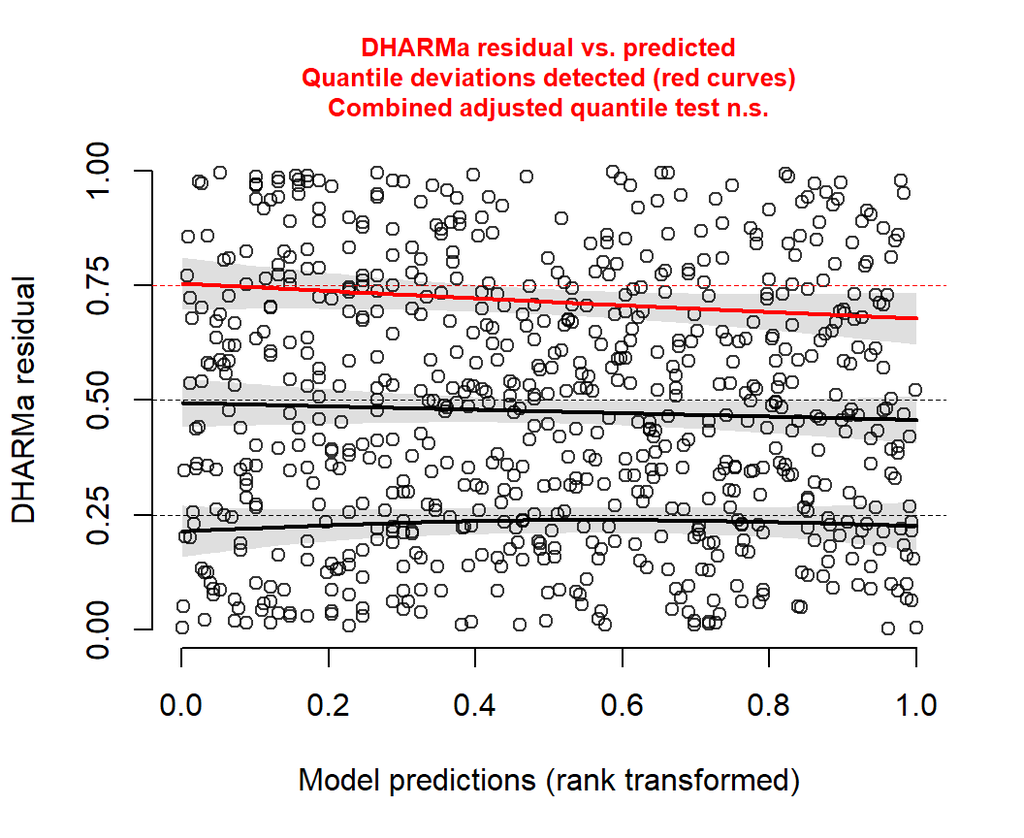

Figure 2: DHARMa residuals against model predictions for mod3

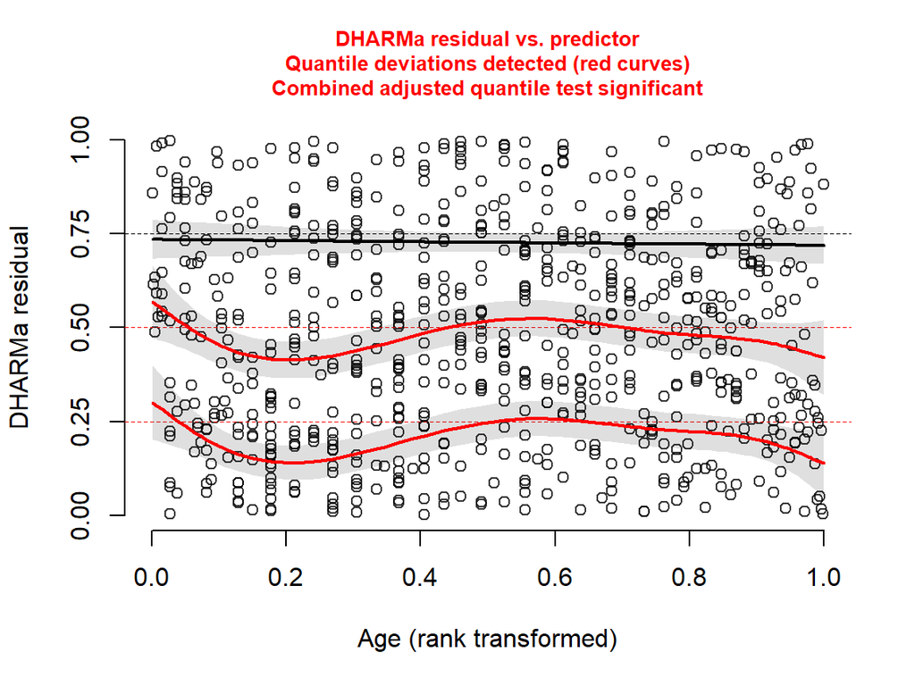

Figure 3: DHARMa residuals against age

Table 4: DHARMa diagnostic tests for mod3

| Test | Statistic | p |
| --- | --- | --- |
| Uniformity of residuals (KS) | 0.047 | 0.080 |
| Dispersion | 0.978 | 0.736 |
| Outliers | 3.000 | 0.394 |

## Collinearity

Table 5: Variance inflation factors for mod3

| Term | VIF | Tolerance |
| --- | --- | --- |
| Sex | 1.07 | 0.93 |
| Pclass | 1.42 | 0.71 |
| Age | 1.33 | 0.75 |

## Complete separation and events per predictor

Table 6: Survival counts within each sex and ticket-class cell

| Sex | Ticket class | Passengers | Survived | Died |
| --- | --- | --- | --- | --- |
| female | 1 | 85 | 82 | 3 |
| female | 2 | 74 | 68 | 6 |
| female | 3 | 102 | 47 | 55 |
| male | 1 | 101 | 40 | 61 |
| male | 2 | 99 | 15 | 84 |
| male | 3 | 253 | 38 | 215 |

## Diagnostic findings

Most assumptions appeared reasonably satisfied. The simulated-residual QQ plot followed the reference line closely, and none of the DHARMa tests detected a problem: uniformity (KS p = .080), dispersion (p = .736), and outliers (p = .394). The DHARMa outlier test also found no more extreme residuals than expected, suggesting that unusual observations were not a major concern. In the plot of residuals against predicted values, the quantile lines curved only slightly, and DHARMa’s combined adjusted quantile test was not significant. Collinearity was not a concern, because the largest variance inflation factor was 1.42, well below the usual threshold of 5. There was no sign of complete separation. Every combination of sex and ticket class contained both survivors and non-survivors (the smallest number of survivors in any cell was 15, and the smallest number of non-survivors was 3), and the model converged with a well-defined Hessian. The model had 290 events (the smaller outcome group) for 4 coefficients, or 72.5 events per coefficient, far above the common guideline of 10.

One potential concern was identified in the plot of residuals against age. DHARMa’s combined quantile test was significant, and the smoothed lines showed a wavy pattern, suggesting that the model may not fully capture the relationship between age and survival. This may be because the model assumes a linear relationship between age and the log-odds of survival, which may not adequately reflect differences across age groups, particularly among younger children. Although age significantly improved model fit, its coefficient should be interpreted cautiously because it represents an overall linear trend. The findings for sex and ticket class remain strongly supported under the current model, although modelling age differently could affect their estimates. Overall, I remain reasonably confident in mod3 as the preferred model among those compared, while acknowledging this limitation.

# 5. Select and report the preferred model

## Model selection

I selected mod3 (sex, ticket class, and age) as my preferred model. It had the lowest AIC (657.3) and BIC (680.1), and each addition of a predictor produced a statistically significant improvement in the likelihood-ratio tests, including age (χ²(1) = 25.15, p < .001). Because BIC applies the stronger penalty for complexity and still favoured mod3, the extra parameters are justified. The diagnostics did not show any serious problems with mod3, apart from the mild nonlinearity in the age effect. The model is also easy to interpret, since each predictor corresponds to one of the substantive questions the analysis set out to address (sex, socioeconomic status, and age). I preferred mod3 to mod2 because age improved fit significantly and has a clear substantive meaning, and to mod1 and mod0 because they leave out predictors that clearly improved fit. Mod2 remains a reasonable alternative for a reader who is concerned about the linear form of the age effect.

## Coefficient table

Table 7: Unstandardized logistic regression coefficients (log-odds) and odds ratios for the selected model

| Predictor | Estimate | SE | 95% CI (log-odds) Lower | 95% CI (log-odds) Upper | p | Odds ratio OR | Odds ratio Lower | Odds ratio Upper |
| --- | --- | --- | --- | --- | --- | --- | --- | --- |
| Intercept | 3.777 | 0.401 | 2.991 | 4.563 | < .001 | 43.685 | 19.902 | 95.888 |
| Sex: male (vs. female) | −2.523 | 0.207 | −2.929 | −2.116 | < .001 | 0.080 | 0.053 | 0.120 |
| Ticket class: second (vs. first) | −1.310 | 0.278 | −1.855 | −0.765 | < .001 | 0.270 | 0.156 | 0.465 |
| Ticket class: third (vs. first) | −2.581 | 0.281 | −3.132 | −2.029 | < .001 | 0.076 | 0.044 | 0.131 |
| Age (per year) | −0.037 | 0.008 | −0.052 | −0.022 | < .001 | 0.964 | 0.949 | 0.978 |

## Interpreting the coefficients

Sex: Holding ticket class and age constant, the log-odds of survival were 2.52 lower for men than for women, 95% CI [-2.93, -2.12], p < .001. As an odds ratio, the odds of survival for men were .08 times the odds for women (95% CI [.05, .12]), which is a reduction of about 92%.

Ticket class: Holding sex and age constant, passengers in second class had log-odds of survival 1.31 lower than passengers in first class, 95% CI [-1.85, -.76], p < .001, an odds ratio of .27 (95% CI [.16, .47]). Third-class passengers had log-odds of survival 2.58 lower than first-class passengers, 95% CI [-3.13, -2.03], p < .001, an odds ratio of .08 (95% CI [.04, .13]).

Age: Holding sex and ticket class constant, each additional year of age was associated with a .037 decrease in the log-odds of survival, 95% CI [-.052, -.022], p < .001. The odds ratio of .964 (95% CI [.949, .978]) means that each additional year multiplied the odds of survival by about that amount, or .69 for every ten years.

The intercept is the log-odds of survival (3.78) for a female first-class passenger aged 0, so it serves as a baseline and not as a typical passenger.

## Overall model performance

Table 8: Overall performance of the selected model

| Model | AIC | BIC | logLik | deviance | Tjur's R² |
| --- | --- | --- | --- | --- | --- |
| mod3: Sex + Pclass + Age | 657.28 | 680.14 | −323.64 | 647.28 | 0.402 |

The selected model had an AIC of 657.3, a BIC of 680.1, and a deviance of 647.3 (compared with 964.5 for the null model). Tjur’s R² was .402, meaning that the model’s predicted probability of survival was on average about 40 percentage points higher for passengers who survived than for those who died. This describes fit to these 714 passengers, not how well the model would predict survival in new data.

## Summary of results

I examined the association between sex, ticket class (a proxy for socioeconomic status), and age and survival of the Titanic sinking among 714 passengers, using four nested binary logistic regression models. Likelihood-ratio tests, AIC, and BIC all favoured the model with all three predictors (mod3). In that model, holding the other predictors constant, the odds of survival for men were .08 times the odds for women (95% CI [.05, .12]). The odds of survival for second-class passengers were .27 times those of first-class passengers (95% CI [.16, .47]), and for third-class passengers they were .08 times those of first-class passengers (95% CI [.04, .13]). Each additional year of age multiplied the odds of survival by .964 (95% CI [.949, .978]). Diagnostics supported the model overall, with one caveat about the linearity of the age effect.

## Visualizing age

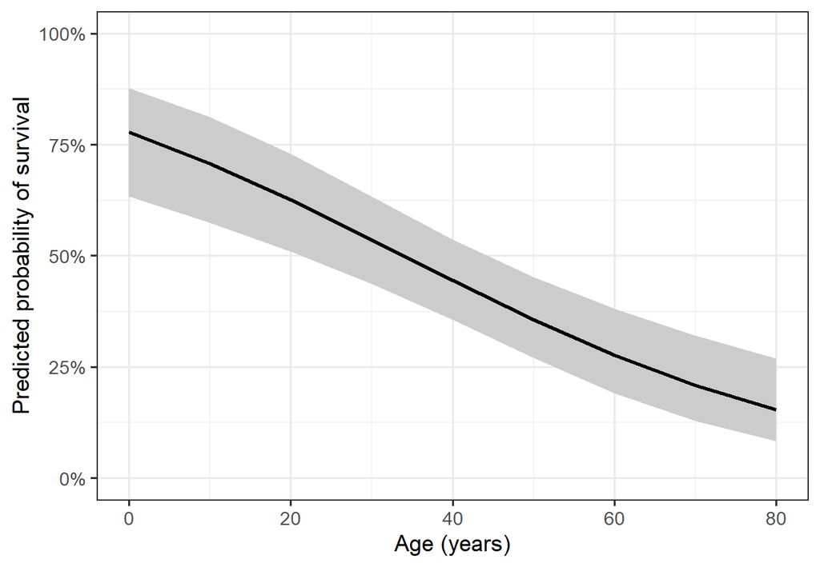

# 6. Discussion and limitations

Sex appeared to be the strongest predictor of survival, followed by ticket class, and then age. Adding sex to the null model produced the largest improvement in fit (χ²(1) = 213.8), ticket class added a substantial improvement beyond sex (χ²(2) = 78.3), and age added the smallest improvement (χ²(1) = 25.1), although all three were statistically significant. The odds ratios show the same ordering. Men had far lower odds of survival than women (OR = .08), third-class passengers had far lower odds than first-class passengers (OR = .08), and each additional year of age reduced the odds only modestly (OR = .964 per year). These results are consistent with the historical account that women, first-class passengers, and children were prioritized in the evacuation.

Several limitations should be considered when interpreting these findings. First, the data are observational and come from a single historical event, meaning that the results demonstrate associations rather than causal relationships. Second, the analysis included only 714 passengers with complete data, excluding 177 passengers with missing age information. This may limit how well the findings represent all passengers in the original dataset. Third, ticket class was used as an indicator of socioeconomic status, but it may not fully capture differences in wealth or other factors, such as cabin location, that could have influenced survival. Another limitation concerns age, as the diagnostic results suggested that its relationship with the log-odds of survival may not be entirely linear. Therefore, the age coefficient should be interpreted cautiously because it may not fully capture differences in survival across age groups, particularly among younger children. Additionally, the models did not examine possible interactions between predictors. For example, the relationship between sex and survival may have differed across ticket classes. Finally, the model performance was evaluated using the same passengers included in the analysis, so the results do not necessarily reflect how well the model would perform on new data.